# Ford GoBike Dataset Exploration

## Preliminary Wrangling

Bay Wheels (formerly Ford GoBike) is the Bay Area’s premier bikeshare system, and one of the largest in the nation. Get access to thousands of bikes and see public transit schedules around you in San Francisco, Oakland, Berkeley, Emeryville, and San Jose. Best of all, it’s available 24/7.

Bay Wheels consists of a fleet of specially-designed, sturdy, and durable electric bikes that can be accessed throughout the Bay Area, as well as classic bikes that are locked into a network of docking stations in Bay Area cities.The bikes can be unlocked from one station and returned to any other station in the system, making them ideal for one-way trips.

This data set includes information about individual rides made in a bike-sharing system covering the greater San Francisco Bay area in feb, 2019.

```python
# import all packages and set plots to be embedded inline
import numpy as np
import pandas as pd
import matplotlib.pyplot as plt
import seaborn as sb

%matplotlib inline
```

### Data Loading and Assesing

```python
# load in the dataset into a pandas dataframe, print statistics
fordgobike = pd.read_csv('fordgobike-tripdata.csv')
```

```python
# high-level overview of data shape and composition
print(fordgobike.info())
print(fordgobike.shape)
print(fordgobike.dtypes)
print(fordgobike.sample(30))
```

```
<class 'pandas.core.frame.DataFrame'>
RangeIndex: 183412 entries, 0 to 183411
Data columns (total 16 columns):
 #   Column                   Non-Null Count   Dtype
---  ------                   --------------   -----
 0   duration_sec             183412 non-null  int64
 1   start_time               183412 non-null  object
 2   end_time                 183412 non-null  object
 3   start_station_id         183215 non-null  float64
 4   start_station_name       183215 non-null  object
 5   start_station_latitude   183412 non-null  float64
 6   start_station_longitude  183412 non-null  float64
 7   end_station_id           183215 non-null  float64
 8   end_station_name         183215 non-null  object
 9   end_station_latitude     183412 non-null  float64
```

[output cut: 218 more lines]

```python
# Check duplicates
fordgobike.duplicated().sum()
```

```
0
```

```python
#check nulls
fordgobike.isnull().sum()
```

```
duration_sec                  0
start_time                    0
end_time                      0
start_station_id            197
start_station_name          197
start_station_latitude        0
start_station_longitude       0
end_station_id              197
end_station_name            197
end_station_latitude          0
end_station_longitude         0
bike_id                       0
user_type                     0
member_birth_year          8265
member_gender              8265
bike_share_for_all_trip       0
dtype: int64
```

```python
fordgobike.describe()
```

|  | duration_sec | start_station_id | start_station_latitude | start_station_longitude | end_station_id | end_station_latitude | end_station_longitude | bike_id | member_birth_year |
| --- | --- | --- | --- | --- | --- | --- | --- | --- | --- |
| count | 183412.000000 | 183215.000000 | 183412.000000 | 183412.000000 | 183215.000000 | 183412.000000 | 183412.000000 | 183412.000000 | 175147.000000 |
| mean | 726.078435 | 138.590427 | 37.771223 | -122.352664 | 136.249123 | 37.771427 | -122.352250 | 4472.906375 | 1984.806437 |
| std | 1794.389780 | 111.778864 | 0.099581 | 0.117097 | 111.515131 | 0.099490 | 0.116673 | 1664.383394 | 10.116689 |
| min | 61.000000 | 3.000000 | 37.317298 | -122.453704 | 3.000000 | 37.317298 | -122.453704 | 11.000000 | 1878.000000 |
| 25% | 325.000000 | 47.000000 | 37.770083 | -122.412408 | 44.000000 | 37.770407 | -122.411726 | 3777.000000 | 1980.000000 |
| 50% | 514.000000 | 104.000000 | 37.780760 | -122.398285 | 100.000000 | 37.781010 | -122.398279 | 4958.000000 | 1987.000000 |
| 75% | 796.000000 | 239.000000 | 37.797280 | -122.286533 | 235.000000 | 37.797320 | -122.288045 | 5502.000000 | 1992.000000 |
| max | 85444.000000 | 398.000000 | 37.880222 | -121.874119 | 398.000000 | 37.880222 | -121.874119 | 6645.000000 | 2001.000000 |

## Quality issues

1- The start_time, end_times, user_type, and member_gender columns are object type.

2- The start_station_id, end_station_id, and member_birth_year columns are float.

3- The bike_id column is integer

## Tidiness issues

1- The member_birth_year column doesn't represent the age of members correctly.

2- start_time and end_times containg information about the month, day and hour of the trips but in very confusing way.

3- start_station_latitude, start_station_longitude, end_station_latitude, and end_station_longitude columns contain information about the position of the start and end stations in inappropriate way.

4- There is no columns represnts the velocity of trips.

5- The duration of trips in seconds may be confused.

### Data Cleaning

```python
#Perform some wrangling
#Change the start_time and end_time columns to date type
fordgobike['start_time'] = pd.to_datetime(fordgobike['start_time'])
fordgobike['end_time'] = pd.to_datetime(fordgobike['end_time'])

#Change the user_type and member_gender columns to category type
fordgobike['user_type'] = fordgobike['user_type'].astype('category')
fordgobike['member_gender'] = fordgobike['member_gender'].astype('category')

#convert the start_station_id, end_station_id and bike_id columns to string
fordgobike['start_station_id'] = fordgobike['start_station_id'].astype(str)
fordgobike['end_station_id'] = fordgobike['end_station_id'].astype(str)
fordgobike['bike_id'] = fordgobike['bike_id'].astype(str)
```

```python
#Calculate the distances in meters between the start and end stations
from geopy.distance import geodesic

#Create a function to calculate the distances from the lattitude and longitude of stations
def distance_calc (row):
    """
    Calculate the distance between two points using the lattitude and longitude .

    Args:
        row: the latitude and longitude of the start and stop stations are obtained by the read function row.
    Returns:
        The distance between the start and stop stations in meters is calculated using geodesic function.
    """
    start = (row['start_station_latitude'], row['start_station_longitude'])
    stop = (row['end_station_latitude'], row['end_station_longitude'])

    return geodesic(start, stop).meters

#create calc_dist column to store the calculated distances
fordgobike['calc_dist'] = fordgobike.apply (lambda row: distance_calc (row),axis=1)
```

```python
#change the duration time to float and the convert the unit to minute
fordgobike['duration_min'] = fordgobike['duration_sec'] / 60

#create velocity in meter per seconds column of each trip
fordgobike['velocity'] = fordgobike['calc_dist'] / fordgobike['duration_sec']

#create columns for trip start date in yyyy-mm-dd format, trip start hour of the day, day of week
fordgobike['start_date'] = fordgobike.start_time.dt.strftime('%Y-%m-%d')
fordgobike['start_hour_ofday'] = fordgobike.start_time.dt.strftime('%H')
fordgobike['start_day_ofweek'] = fordgobike.start_time.dt.strftime('%A')

#Create a column for the age of riders
fordgobike['member_age'] = 2019 - fordgobike['member_birth_year']
```

```python
#create a column for the day of week to be categories into weekend or work days
fordgobike['WEEKDAY'] = pd.to_datetime(fordgobike['start_time']).dt.dayofweek
fordgobike['day_type'] = 0
fordgobike.loc[fordgobike['WEEKDAY'].isin([5, 6]), 'day_type'] = 'weekend'  # 5 and 6 correspond to Sat and Sun
fordgobike.loc[fordgobike['WEEKDAY'].isin([0, 1, 2, 3, 4]), 'day_type'] = 'work_days'
fordgobike['day_type'] = fordgobike['day_type'].astype('category')
```

```python
# Drop unused columns
fordgobike.drop(['duration_sec', 'start_time', 'end_time', 'start_station_latitude',
       'start_station_longitude', 'end_station_latitude', 'end_station_longitude', 'start_station_id', 'end_station_id', 'member_birth_year','start_date' ], axis = 1, inplace = True)
```

```python
# Check the cleaning process
print(fordgobike.info())
print(fordgobike.shape)
print(fordgobike.dtypes)
print(fordgobike.head(10))

# Save the cleaned version
fordgobike.to_csv(r'C:\Users\user\fordgobike-tripdata_cleaned.csv', index=False)
```

```
<class 'pandas.core.frame.DataFrame'>
RangeIndex: 183412 entries, 0 to 183411
Data columns (total 14 columns):
 #   Column                   Non-Null Count   Dtype
---  ------                   --------------   -----
 0   start_station_name       183215 non-null  object
 1   end_station_name         183215 non-null  object
 2   bike_id                  183412 non-null  object
 3   user_type                183412 non-null  category
 4   member_gender            175147 non-null  category
 5   bike_share_for_all_trip  183412 non-null  object
 6   calc_dist                183412 non-null  float64
 7   duration_min             183412 non-null  float64
 8   velocity                 183412 non-null  float64
 9   start_hour_ofday         183412 non-null  object
 10  start_day_ofweek         183412 non-null  object
 11  member_age               175147 non-null  float64
 12  WEEKDAY                  183412 non-null  int64
 13  day_type                 183412 non-null  category
dtypes: category(3), float64(4), int64(1), object(6)
memory usage: 15.9+ MB
None
(183412, 14)
start_station_name           object
end_station_name             object
bike_id                      object
user_type                  category
member_gender              category
bike_share_for_all_trip      object
calc_dist                   float64
duration_min                float64
velocity                    float64
start_hour_ofday             object
start_day_ofweek             object
member_age                  float64
WEEKDAY                       int64
day_type                   category
dtype: object
                                 start_station_name  \
0  Montgomery St BART Station (Market St at 2nd St)
```

[output cut: 30 more lines]

```
7          Male                      No  4526.202512     26.916667  2.802602
8         Other                      No  4526.202512     26.166667  2.882932
9          Male                      No  3660.261158     17.483333  3.489286

  start_hour_ofday start_day_ofweek  member_age  WEEKDAY   day_type
0               17         Thursday        35.0        3  work_days
1               18         Thursday         NaN        3  work_days
2               12         Thursday        47.0        3  work_days
3               17         Thursday        30.0        3  work_days
4               23         Thursday        45.0        3  work_days
5               23         Thursday        60.0        3  work_days
6               23         Thursday        36.0        3  work_days
7               23         Thursday        30.0        3  work_days
8               23         Thursday        31.0        3  work_days
9               23         Thursday        27.0        3  work_days
```

```python
#show the dataset main statistics
fordgobike.describe()
```

|  | calc_dist | duration_min | velocity | member_age | WEEKDAY |
| --- | --- | --- | --- | --- | --- |
| count | 183412.000000 | 183412.000000 | 183412.000000 | 175147.000000 | 183412.000000 |
| mean | 1690.555001 | 12.101307 | 2.993813 | 34.193563 | 2.632178 |
| std | 1097.157550 | 29.906496 | 1.096705 | 10.116689 | 1.814786 |
| min | 0.000000 | 1.016667 | 0.000000 | 18.000000 | 0.000000 |
| 25% | 909.777251 | 5.416667 | 2.405862 | 27.000000 | 1.000000 |
| 50% | 1429.906504 | 8.566667 | 3.065881 | 32.000000 | 3.000000 |
| 75% | 2226.168609 | 13.266667 | 3.703189 | 39.000000 | 4.000000 |
| max | 69465.977135 | 1424.066667 | 10.002301 | 141.000000 | 6.000000 |

### What is the structure of your dataset?

There are 183412 trips in the dataset with information about the timing of trips (start time, end time and duration in seconds), start stations (id, name, latitude and longitude), end stations (id, name, latitude and longitude), bike id, the user type (customer or Subscriber), the members (gender and birth date) and bike share for all trip which tracks members who are enrolled in the Bike Share for All program for low-income residents.

### What is/are the main feature(s) of interest in your dataset?

I'm most interested in figuring out:

2- The peak hours, day of weeks and month of the trips to figure out the rush times.

3- The characterstics asscociated with riders with duration trips above the average to figure out the main target customers.

4- The most common stations used as start or end.

5- The average distance of the most trips.

### What features in the dataset do you think will help support your investigation into your feature(s) of interest?

The characterstics of the customers (gender, type and age) will help to figure out the main target customers. Also, the hours, day of week and month of the most trips are help to figure out the patterns to determine the rush hours.

## Univariate Exploration

### What is the distribution of the number of trips during day of week?

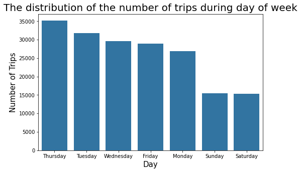

```python
# Use the bar chart to describe the distribution of the number of trips during day of week
plt.figure(figsize=[8, 5])
base_color = sb.color_palette()[0]
order = fordgobike['start_day_ofweek'].value_counts().index

sb.countplot(data=fordgobike, x='start_day_ofweek', color=base_color , order=order);
plt.title('The distribution of the number of trips during day of week', fontsize=20)
plt.xlabel('Day', fontsize=15);
plt.ylabel('Number of Trips', fontsize=15);
```

###### Observation: The most of trips occur during the days of work and customers usually used the service for work transportation.While, the weekend days have the least number of trips.

### What is the distribution of the number of trips during hour of day?

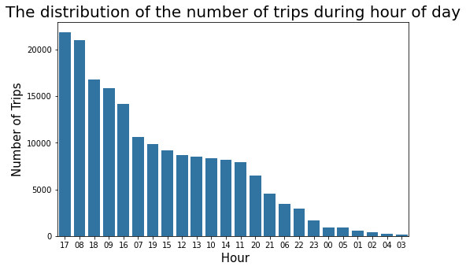

```python
# Use the bar chart to describe the distribution of the number of trips during hour of day
plt.figure(figsize=[8, 5])
base_color = sb.color_palette()[0]
order = fordgobike['start_hour_ofday'].value_counts().index

sb.countplot(data=fordgobike, x='start_hour_ofday', color=base_color , order=order);
plt.title('The distribution of the number of trips during hour of day', fontsize=20)
plt.xlabel(' Hour', fontsize=15);
plt.ylabel('Number of Trips', fontsize=15);
```

### What is the distribution of the number of trips of the top ten start and end stations?

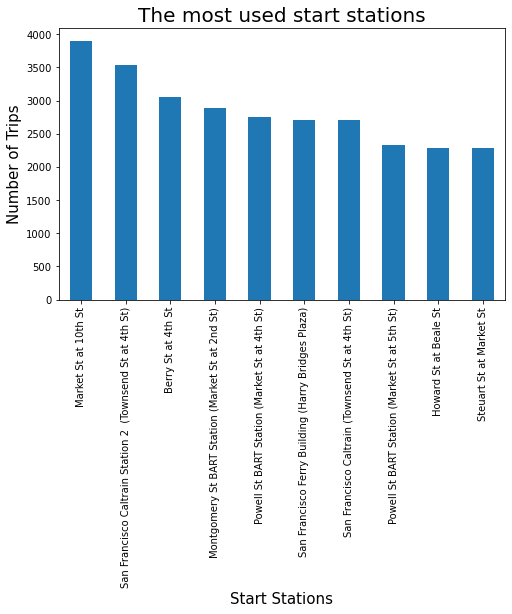

```python
# Plot the top ten most stations used as start stations
plt.figure(figsize=[8, 5])
fordgobike['start_station_name'].value_counts()[0:10].sort_values(ascending=False).plot(kind = 'bar');
plt.title('The most used start stations', fontsize=20)
plt.ylabel('Number of Trips', fontsize=15)
plt.xlabel('Start Stations', fontsize=15)
```

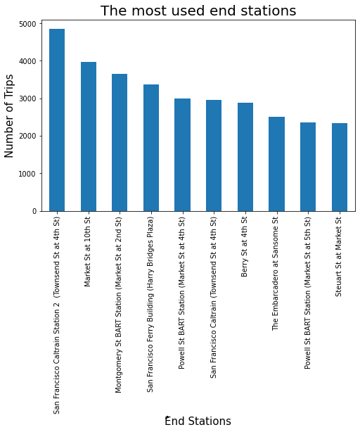

```python
# Plot the top ten most stations used as end stations
plt.figure(figsize=[8, 5])
fordgobike['end_station_name'].value_counts()[0:10].sort_values(ascending=False).plot(kind = 'bar');
plt.title('The most used end stations', fontsize=20)
plt.ylabel('Number of Trips', fontsize=15)
plt.xlabel('ُEnd Stations', fontsize=15)
```

##### Obsevation: The pattern of the most used stations show that the top used station are used frequently for work transportations

### What is the characterstics of the rides with respect to the user type?

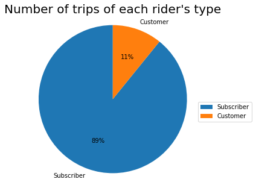

```python
# Use the pie chart to describee the distribution of the number of trips versus the member type

plt.figure(figsize=[8, 5])
sorted_counts = fordgobike['user_type'].value_counts()
plt.pie(sorted_counts, labels = sorted_counts.index, startangle = 90, autopct='%1.0f%%');
plt.title('The most used end stations', fontsize=20)
plt.axis('square');
plt.title("Number of trips of each rider's type", fontsize=20);
plt.legend(bbox_to_anchor=(1,0.5), loc="upper left");
```

###### Observation: About 89% of the riders are Subscribers which may consistents with that almost trips time are occure at the work transportation times.

### What is the characterstics of the rides with respect to the member gender?

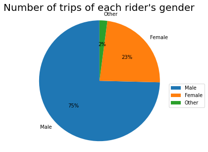

```python
# Use the pie chart to describee the distribution of the number of trips versus the member gender
plt.figure(figsize=[8, 5])
sorted_counts = fordgobike['member_gender'].value_counts()
plt.pie(sorted_counts, labels = sorted_counts.index, startangle = 90, autopct='%1.0f%%');
plt.axis('square');
plt.title("Number of trips of each rider's gender", fontsize=20);
plt.legend(bbox_to_anchor=(1,0.5), loc="upper left");
```

###### Observation: Men are about 75% of the riders which because that the bike riding needs a high physical exertion. One of the suggestion to increase the number of women is using the electric bicycles also known as an e-bikes. e-bike is a bicycle with an integrated electric motor which can be used to assist propulsion.

### What is the characterstics of the rides with respect to the the low-income resident subscriptions?

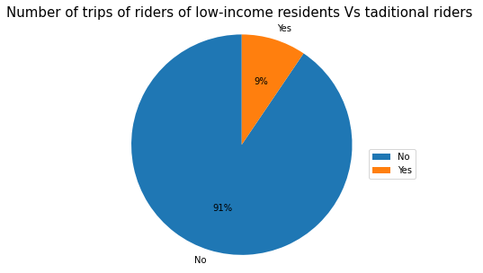

```python
# Use the pie chart to describee the distribution of the number of trips versus the subscription type
plt.figure(figsize=[8, 5])
sorted_counts = fordgobike['bike_share_for_all_trip'].value_counts()
plt.pie(sorted_counts, labels = sorted_counts.index, startangle = 90, autopct='%1.0f%%');
plt.axis('square');
plt.title("Number of trips of riders of low-income residents Vs taditional riders ", fontsize=15);
plt.legend(bbox_to_anchor=(1,0.5), loc="upper left");
```

##### Oservation: The ratio of the low-income resident riders is consistent with their percentage to the total population.

### What is the distribution of member ages?

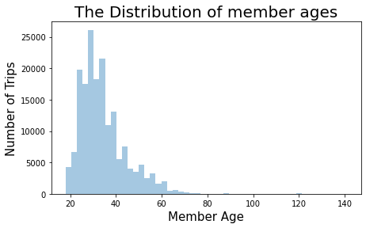

```python
# Use the histogram to describe the distribution of the member ages versus the number of trips
plt.figure(figsize=[7, 4])
base_color = sb.color_palette()[0]
sb.distplot(fordgobike['member_age'], kde=False, color=base_color);
plt.title("The Distribution of member ages", fontsize=20);
plt.xlabel('Member Age', fontsize=15);
plt.ylabel('Number of Trips', fontsize=15);
```

##### Observation: The distribution of the age of members have outliers while the most durations within 80 years. So that, let us zoom the range to figure out the distribution of the duration of the most trips

```python
# Describe the statistics of the member ages
fordgobike['member_age'].describe(percentiles=[.85, .9, .95, .99])
```

```
count    175147.000000
mean         34.193563
std          10.116689
min          18.000000
50%          32.000000
85%          45.000000
90%          49.000000
95%          55.000000
99%          64.000000
max         141.000000
Name: member_age, dtype: float64
```

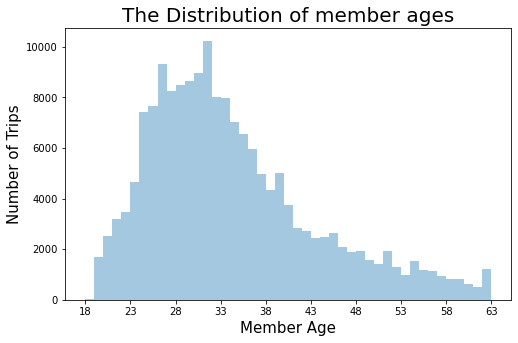

```python
# Plot the The member age distribution over the the 99% of the age scale to exclude the outliers
plt.figure(figsize=[8, 5])
base_color = sb.color_palette()[0]
bins = np.arange(18, 64, 1)
ticks = np.arange(18, 64, 5)
sb.distplot(fordgobike['member_age'], kde=False, bins=bins, color=base_color);
plt.xticks(ticks, ticks);
plt.title("The Distribution of member ages", fontsize=20);
plt.xlabel('Member Age', fontsize=15);
plt.ylabel('Number of Trips', fontsize=15);
```

##### Observation: Most members were around 23 to 43 years old which consitent with the high physical exertion required y the bike riding. e-bikes will be a good solution to increase the trips of older members

### What is the distribution of the durations of the trips?

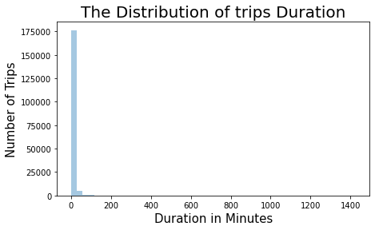

```python
# Use the histogram to describe the distribution of the trips durations versus the number of trips
plt.figure(figsize=[7, 4])
base_color = sb.color_palette()[0]

sb.distplot(fordgobike['duration_min'], kde=False, color=base_color);
plt.title("The Distribution of trips Duration", fontsize=20);
plt.xlabel('Duration in Minutes', fontsize=15);
plt.ylabel('Number of Trips', fontsize=15);
```

##### Observation: The distribution of the duration has outliers while the most durations within 100 minutes. So that, let us zoom the range to figure out the distribution of the duration of the most trips

```python
# Describe the statistics of the trips durations
fordgobike['duration_min'].describe(percentiles=[.85, .9, .95, .99])
```

```
count    183412.000000
mean         12.101307
std          29.906496
min           1.016667
50%           8.566667
85%          16.683333
90%          19.633333
95%          26.183333
99%          57.648167
max        1424.066667
Name: duration_min, dtype: float64
```

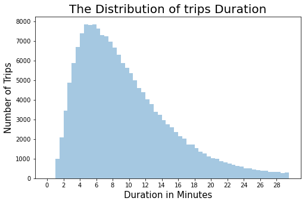

```python
# Plot the The trips duration distribution over the the 95% of the duration scale to exclude the outliers
plt.figure(figsize=[8, 5])
base_color = sb.color_palette()[0]
bins = np.arange(0, 30, 0.5)
ticks = np.arange(0, 30, 2)
sb.distplot(fordgobike['duration_min'], kde=False, bins=bins, color=base_color);
plt.xticks(ticks, ticks);
plt.title("The Distribution of trips Duration", fontsize=20);
plt.xlabel('Duration in Minutes', fontsize=15);
plt.ylabel('Number of Trips', fontsize=15);
```

##### Observation: Most duration of trips were around 4 to 16 minutes which consistent with the fact that most trips are used for work transportations

### What is the distribution of the trips distances?

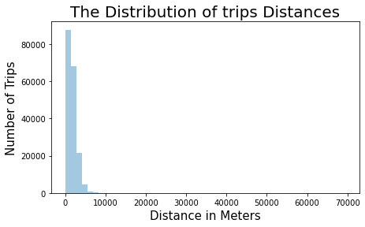

```python
# Use the histogram to describe the distribution of the trips distances versus the number of trips

plt.figure(figsize=[7, 4])
base_color = sb.color_palette()[0]

sb.distplot(fordgobike['calc_dist'], kde=False, color=base_color);
plt.title("The Distribution of trips Distances", fontsize=20);
plt.xlabel('Distance in Meters', fontsize=15);
plt.ylabel('Number of Trips', fontsize=15);
```

##### Oservation: The distribution of the distance has outliers while the most durations within 4000 meters. So that, let us zoom the range to figure out the distribution of the distance of the most trips

```python
# Describe the statistics of the trips distances
fordgobike['calc_dist'].describe(percentiles=[.85, .9, .95, .99])
```

```
count    183412.000000
mean       1690.555001
std        1097.157550
min           0.000000
50%        1429.906504
85%        2772.716630
90%        3204.368974
95%        3792.463552
99%        5061.491841
max       69465.977135
Name: calc_dist, dtype: float64
```

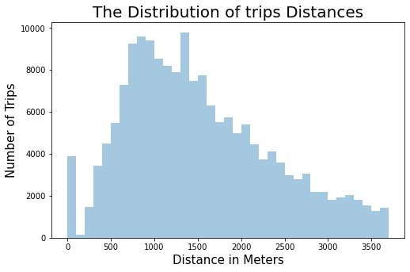

```python
# Plot the trips distances distribution over the the 95% of the duration scale to exclude the outliers
plt.figure(figsize=[8, 5])
base_color = sb.color_palette()[0]
bins = np.arange(0, 3800, 100)
ticks = np.arange(0, 3800, 500)
sb.distplot(fordgobike['calc_dist'], kde=False, bins=bins, color=base_color);
plt.xticks(ticks, ticks);
plt.title("The Distribution of trips Distances", fontsize=20);
plt.xlabel('Distance in Meters', fontsize=15);
plt.ylabel('Number of Trips', fontsize=15);
```

##### Obseravtion: Most duration of trips were around 500 to 3000 meters.

### What is the distribution of the durations of zero distances trips?

```python
# Create a dataframe for the trips of zero distance
zero_dis = fordgobike[fordgobike['calc_dist'] == 0]
zero_dis
```

|  | start_station_name | end_station_name | bike_id | user_type | member_gender | bike_share_for_all_trip | calc_dist | duration_min | velocity | start_hour_ofday | start_day_ofweek | member_age | WEEKDAY | day_type |
| --- | --- | --- | --- | --- | --- | --- | --- | --- | --- | --- | --- | --- | --- | --- |
| 19 | Telegraph Ave at 23rd St | Telegraph Ave at 23rd St | 5629 | Customer | Male | No | 0.0 | 14.566667 | 0.0 | 23 | Thursday | 41.0 | 3 | work_days |
| 27 | Folsom St at 9th St | Folsom St at 9th St | 5410 | Subscriber | Male | No | 0.0 | 6.800000 | 0.0 | 23 | Thursday | 37.0 | 3 | work_days |
| 34 | Valencia St at 22nd St | Valencia St at 22nd St | 5559 | Subscriber | Male | No | 0.0 | 7.850000 | 0.0 | 23 | Thursday | 27.0 | 3 | work_days |
| 53 | Davis St at Jackson St | Davis St at Jackson St | 319 | Customer | NaN | No | 0.0 | 56.966667 | 0.0 | 22 | Thursday | NaN | 3 | work_days |
| 55 | Davis St at Jackson St | Davis St at Jackson St | 1846 | Subscriber | Male | No | 0.0 | 57.966667 | 0.0 | 22 | Thursday | 24.0 | 3 | work_days |
| ... | ... | ... | ... | ... | ... | ... | ... | ... | ... | ... | ... | ... | ... | ... |
| 183317 | Hubbell St at 16th St | Hubbell St at 16th St | 5224 | Subscriber | Male | No | 0.0 | 24.600000 | 0.0 | 02 | Friday | 52.0 | 4 | work_days |
| 183318 | Woolsey St at Sacramento St | Woolsey St at Sacramento St | 4913 | Subscriber | Male | No | 0.0 | 14.616667 | 0.0 | 02 | Friday | 32.0 | 4 | work_days |
| 183326 | Raymond Kimbell Playground | Raymond Kimbell Playground | 5366 | Subscriber | Male | No | 0.0 | 95.216667 | 0.0 | 01 | Friday | 47.0 | 4 | work_days |
| 183350 | Haste St at College Ave | Haste St at College Ave | 3232 | Subscriber | Male | Yes | 0.0 | 14.566667 | 0.0 | 01 | Friday | 24.0 | 4 | work_days |
| 183380 | Raymond Kimbell Playground | Raymond Kimbell Playground | 5343 | Subscriber | Male | No | 0.0 | 15.716667 | 0.0 | 00 | Friday | 47.0 | 4 | work_days |

3880 rows × 14 columns

```python
# the statistics of the duration of the zero-distance trips
zero_dis['duration_min'].describe(percentiles=[.85, .9, .95, .99])
```

```
count    3880.000000
mean       32.838011
std        81.370704
min         1.016667
50%        16.658333
85%        48.533333
90%        59.788333
95%        98.934167
99%       259.100667
max      1373.083333
Name: duration_min, dtype: float64
```

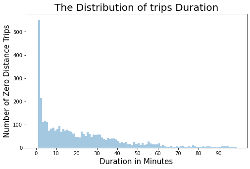

```python
# Plot the trips durations distribution over the the 95% of the duration scale to exclude the outliers
plt.figure(figsize=[8, 5])
base_color = sb.color_palette()[0]
bins = np.arange(0, 100, 1)
ticks = np.arange(0, 100, 10)
sb.distplot(zero_dis['duration_min'], kde=False, bins=bins, color=base_color);
plt.xticks(ticks, ticks);
plt.title("The Distribution of trips Duration", fontsize=20);
plt.xlabel('Duration in Minutes', fontsize=15);
plt.ylabel('Number of Zero Distance Trips', fontsize=15);
```

##### Observation: The distribution of duration of the zero-distance trips are very right skewed. A log-scale on the x-axis should be used to have a data follow the normal distribution.

```python
# the log-scale statistics of the duration of the zero-distance trips
np.log10(zero_dis['duration_min'].describe())
```

```
count    3.588832
mean     1.516377
std      1.910468
min      0.007179
25%      0.676312
50%      1.221632
75%      1.537819
max      3.137697
Name: duration_min, dtype: float64
```

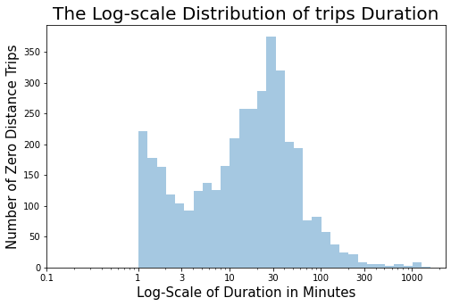

```python
# Plot the trips durations distribution using the log-scale transformation
plt.figure(figsize=[8, 5])
base_color = sb.color_palette()[0]
bins = 10 ** np.arange(0.007, 3.14+0.1, 0.1)
ticks = [ 0.1, 1, 3, 10, 30, 100, 300, 1000]
sb.distplot(zero_dis['duration_min'], kde=False, bins=bins, color=base_color);
plt.xscale('log')

plt.xticks(ticks, ticks);
plt.title("The Log-scale Distribution of trips Duration", fontsize=20);
plt.xlabel('Log-Scale of Duration in Minutes', fontsize=15);
plt.ylabel('Number of Zero Distance Trips', fontsize=15);
```

##### Obsevation: Most duration of trips were around 7 to 50 minutes which is a wide range of variaty consistents with the picnic style.

### What is the distribution of the trips velocities?

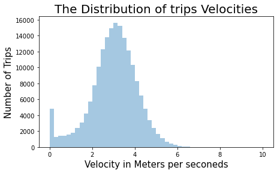

```python
# Use the histogram to describe the distribution of the trips velocities versus the number of trips

plt.figure(figsize=[7, 4])
base_color = sb.color_palette()[0]

sb.distplot(fordgobike['velocity'], kde=False, color=base_color);
plt.title("The Distribution of trips Velocities", fontsize=20);
plt.xlabel('Velocity in Meters per seconeds', fontsize=15);
plt.ylabel('Number of Trips', fontsize=15);
```

##### Observation: The distribution of the velocity has outliers while the most durations within 6 meter per seconed. So that, let us zoom the range to figure out the distribution of the velocity of the most trips.

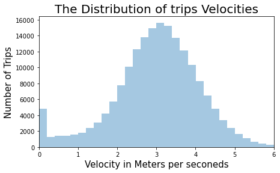

```python
# Plot the trips velocities distribution over a limited velocity scale at 6 m/s to exclude the outliers

plt.figure(figsize=[7, 4])
base_color = sb.color_palette()[0]
sb.distplot(fordgobike['velocity'], kde=False, color=base_color);
plt.xlim((0, 6))
plt.title("The Distribution of trips Velocities", fontsize=20);
plt.xlabel('Velocity in Meters per seconeds', fontsize=15);
plt.ylabel('Number of Trips', fontsize=15);
```

### Next up, lets discuss the characterstics of the rides with zero distance

### What is the distribution of the number of zero-distabce trips during day of week?

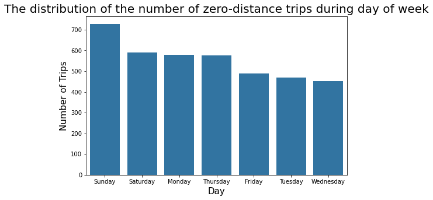

```python
# Use the bar chart to describe the distribution of the number of zero-distance trips versus the day of week

plt.figure(figsize=[8, 5])
base_color = sb.color_palette()[0]
order = zero_dis['start_day_ofweek'].value_counts().index

sb.countplot(data=zero_dis, x='start_day_ofweek', color=base_color , order=order);
plt.title('The distribution of the number of zero-distance trips during day of week', fontsize=20)
plt.xlabel('Day', fontsize=15);
plt.ylabel('Number of Trips', fontsize=15);
```

###### Observation: The weekends obsesses the larger number of zero-distance trips. While, the last three work days: Wednesday, Tuesday, and Friday have the smallest number of the zero-distance trips.

### What is the distribution of the number of zero-distabce trips during hour of day?

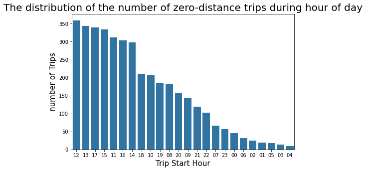

```python
# Use the bar chart to describe the distribution of the number of zero-distance trips versus the hour of day

plt.figure(figsize=[8, 5])
base_color = sb.color_palette()[0]
order = zero_dis['start_hour_ofday'].value_counts().index

sb.countplot(data=zero_dis, x='start_hour_ofday', color=base_color , order=order);
plt.title('The distribution of the number of zero-distance trips during hour of day', fontsize=20)
plt.xlabel('Trip Start Hour', fontsize=15);
plt.ylabel('number of Trips', fontsize=15);
```

###### Observation: The middle day sunny hours obsesse the largest number of zero-distance trips.

### What is the distribution of the number of zero-distabce trips versus the member gender and type?

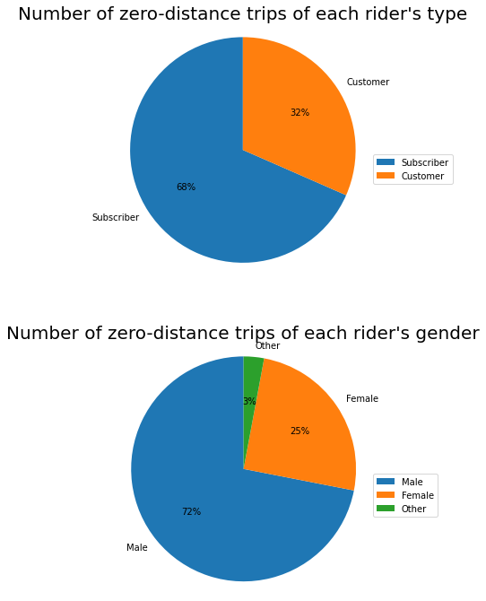

```python
plt.figure(figsize=[5, 12])
# using the pie-plot to describe the member gender distriution of the zero distance trips
plt.subplot(2, 1, 1)
sorted_counts = zero_dis['user_type'].value_counts()
plt.pie(sorted_counts, labels = sorted_counts.index, startangle = 90, autopct='%1.0f%%');
plt.axis('square');
plt.title("Number of zero-distance trips of each rider's type", fontsize=20);
plt.legend(bbox_to_anchor=(1,0.5), loc="upper left");

# using the pie-plot to describe the member type distriution of the zero distance trips
plt.subplot(2, 1, 2)
sorted_counts = zero_dis['member_gender'].value_counts()
plt.pie(sorted_counts, labels = sorted_counts.index, startangle = 90, autopct='%1.0f%%');
plt.axis('square');
plt.title("Number of zero-distance trips of each rider's gender", fontsize=20);
plt.legend(bbox_to_anchor=(1,0.5), loc="upper left");
```

###### Observation: The member gender ratio is almost the same as the traditional trips. While, the member type distribution for the zero-distance trips shows an increasing of the customers trips.

### What is the distribution of member ages for the zero-distance trips?

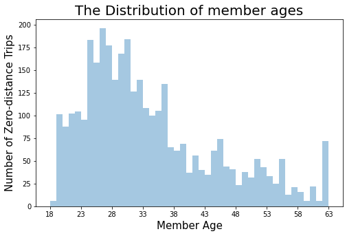

```python
# Use the histogram to describe the distribution of the member ages versus the number of zero-distance trips

plt.figure(figsize=[8, 5])
base_color = sb.color_palette()[0]
bins = np.arange(18, 64, 1)
ticks = np.arange(18, 64, 5)
sb.distplot(zero_dis['member_age'], kde=False, bins=bins, color=base_color);
plt.xticks(ticks, ticks);

plt.title("The Distribution of member ages", fontsize=20);
plt.xlabel('Member Age', fontsize=15);
plt.ylabel('Number of Zero-distance Trips', fontsize=15);
```

##### Observation: Most members were around 19 to 38 years old which is lower than the age distribution for the traditional trips.

### Discuss the distribution(s) of your variable(s) of interest. Were there any unusual points? Did you need to perform any transformations?

During the assessment process, there is no big problems discovered, except some outliers in the member age and duration of trips. Some columns have unsuitable data types. A log-scale transformation is only used for the distribution of the duration of zero-distance trips

### Of the features you investigated, were there any unusual distributions? Did you perform any operations on the data to tidy, adjust, or change the form of the data? If so, why did you do this?

#### unusual distributions

1- The number of trips by women are very small compared to trips of men. A further analysis should be done to explore the reasons and the characterstics of women's trips to dicover the method of encouraging them for more trips

2- The number of trips at the week end is smaller than working days. the charcterstics of weekend trips should be explored.

3- There is more than 2000 trips with zero distance i.e, started and ended at the same station. A further analysis should be done to explore those characterstics.

#### Cleaning Process

1- Convert the data types of some columns such as start_time, end_times, user_type, and member_gender.

2- Create a distance of trips column from the longitude and lattitude of the start and end stations. Then, create create a velocity of trips column from the distance and time columns.

3- Extract the hour per day and day of week fromthe start time column.

4- Delete the unused columns.

## Bivariate Exploration

#### In this section, I investigate relationships between pairs of variables in the data.

### First, lets explore the duration, distannce, velocity, day of week, hour of day, age of member and type versus the gender of riders

### What is the distribution of trips durations over the member gender?

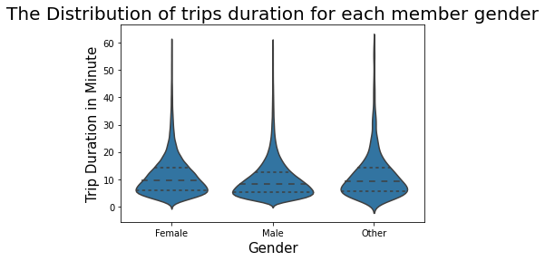

```python
# use violin plot to describe the distribution of the trips durations for each type of the member gender
fordgobike1 = fordgobike[fordgobike['duration_min'] < 60]
sb.violinplot(data=fordgobike1, x='member_gender', y='duration_min', color=base_color, inner='quartile');
plt.title("The Distribution of trips duration for each member gender", fontsize=20);
plt.xlabel('Gender', fontsize=15);
plt.ylabel('Trip Duration in Minute', fontsize=15);
```

###### Observation: Men have the most trips under 10 minutes and women have larger trips average duration

### What is the distribution of trips distances over the member gender?

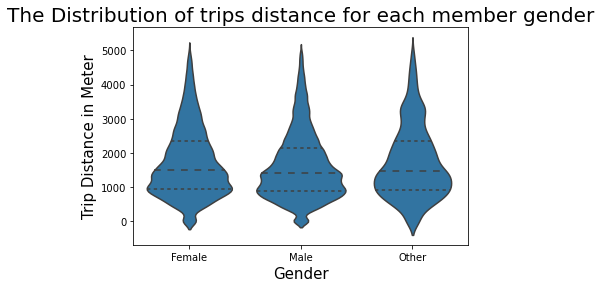

```python
# use violin plot to describe the distribution of the trips distances for each type of the member gender

fordgobike2 = fordgobike[fordgobike['calc_dist'] < 5000]
sb.violinplot(data=fordgobike2, x='member_gender', y='calc_dist', color=base_color, inner='quartile');
plt.title("The Distribution of trips distance for each member gender", fontsize=20);
plt.xlabel('Gender', fontsize=15);
plt.ylabel('Trip Distance in Meter', fontsize=15);
```

###### Observation: Men have the most trips under 1500 meters and women have larger trips average distance and larger number of trips over 2000 meters.

### What is the distribution of trips velocities over the member gender?

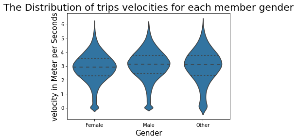

```python
# use violin plot to describe the distribution of the trips velocities for each type of the member gender

fordgobike4 = fordgobike[fordgobike['velocity'] < 6]
sb.violinplot(data=fordgobike4, x='member_gender', y='velocity', color=base_color, inner='quartile');
plt.title("The Distribution of trips velocities for each member gender", fontsize=20);
plt.xlabel('Gender', fontsize=15);
plt.ylabel('velocity in Meter per Seconds', fontsize=15);
```

###### Observation: Men have the larger velocity statistcs than women

### What is the distribution of member age over the member gender?

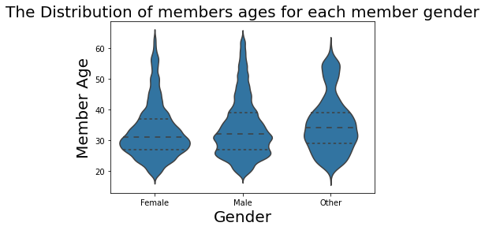

```python
# use violin plot to describe the distribution of the members ages for each type of the member gender

fordgobike3 = fordgobike[fordgobike['member_age'] < 65]
sb.violinplot(data=fordgobike3, x='member_gender', y='member_age', color=base_color, inner='quartile');
plt.title("The Distribution of members ages for each member gender", fontsize=20);
plt.xlabel('Gender', fontsize=20);
plt.ylabel('Member Age', fontsize=20);
```

###### Observation: Men have the larger number of riders at middle and older ages. While, women have the most riders of younger ages.

### What is the distribution of number of trips over the day of week for each member gender?

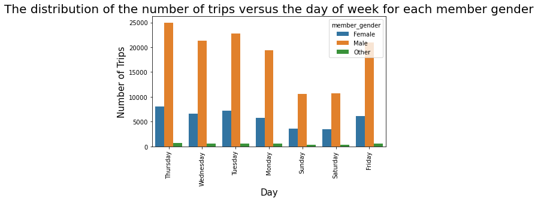

```python
# Use the clustered bar chart to describe the distribution of the number of trips versus the day of week for each member gender

plt.figure(figsize=[7, 4])
sb.countplot(data = fordgobike, x = 'start_day_ofweek', hue = 'member_gender');
plt.xticks(rotation = 90);
plt.title("The distribution of the number of trips versus the day of week for each member gender", fontsize=20);
plt.xlabel('Day', fontsize=15);
plt.ylabel('Number of Trips', fontsize=15);
```

###### Observation: The distribution with respect to the gender's ratio shows a remarkable activity during weekends.

### What is the distribution of number of trips over the hour of day for each member gender?

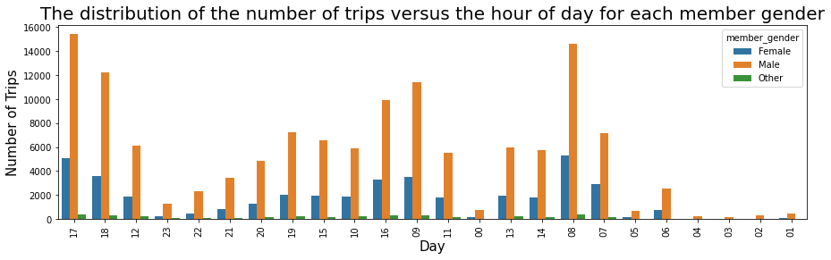

```python
# Use the clustered bar chart to describe the distribution of the number of trips versus the hour of day for each member gender

plt.figure(figsize=[15, 4])
sb.countplot(data = fordgobike, x = 'start_hour_ofday', hue = 'member_gender');
plt.xticks(rotation = 90);
plt.title("The distribution of the number of trips versus the hour of day for each member gender", fontsize=20);
plt.xlabel('Day', fontsize=15);
plt.ylabel('Number of Trips', fontsize=15);
```

###### Observation: The distribution shows a remarkable activity during the work transportations hours.

### What is the distribution of number of trips over the user type for each member gender?

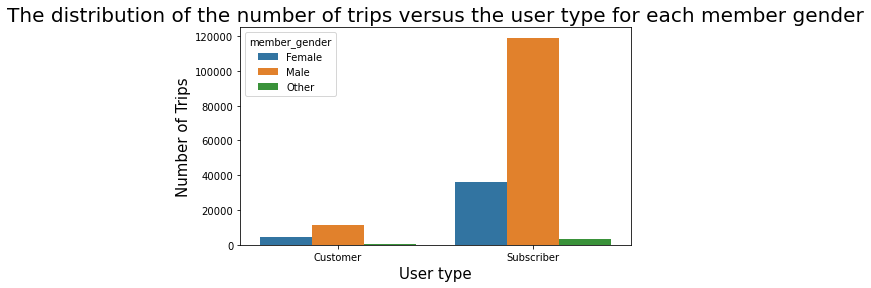

```python
# Use the clustered bar chart to describe the distribution of the number of trips versus the user type for each member gender

plt.figure(figsize=[7, 4])
sb.countplot(data = fordgobike, x = 'user_type', hue = 'member_gender');
plt.title("The distribution of the number of trips versus the user type for each member gender", fontsize=20);
plt.xlabel('User type', fontsize=15);
plt.ylabel('Number of Trips', fontsize=15);
```

###### Observation: Women has larger ratio for the customer type than subscriber type.

### Next up, lets explore the characterstics of the trips at the days of week

### What is the distribution of number of trips over the day of week for each user type?

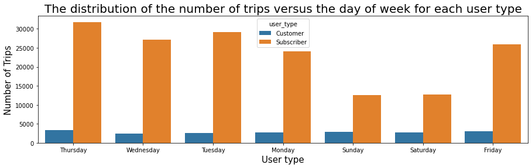

```python
# Use the clustered bar chart to describe the distribution of the number of trips versus the day of week for each user type

plt.figure(figsize=[15, 4])
sb.countplot(data = fordgobike, x = 'start_day_ofweek', hue = 'user_type');
plt.title("The distribution of the number of trips versus the day of week for each user type", fontsize=20);
plt.xlabel('User type', fontsize=15);
plt.ylabel('Number of Trips', fontsize=15);
```

###### Observation: The customers have a constant pattern of using the service over the various days of week, while, the subxcribers use the service at work days higher than weekends.

### What is the descriptive statistics of member ages over the day of week?

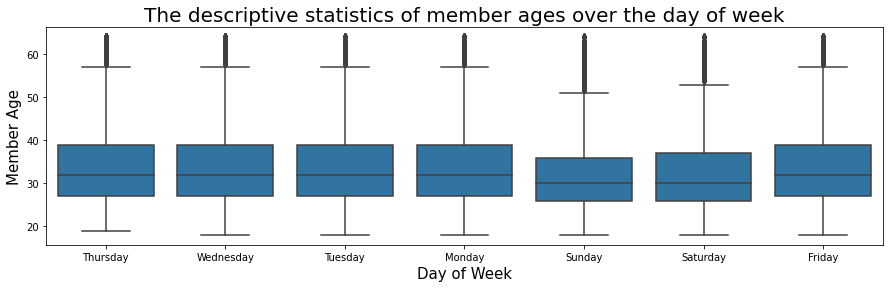

```python
# use box plot to describe the statistics of member ages over the day of week.

plt.figure(figsize=[15, 4])
sb.boxplot(data=fordgobike3, x='start_day_ofweek', y='member_age', color=base_color);
plt.title("The descriptive statistics of member ages over the day of week", fontsize=20);
plt.xlabel('Day of Week', fontsize=15);
plt.ylabel('Member Age', fontsize=15);
```

###### Observation: The member ages are lower at weekends.

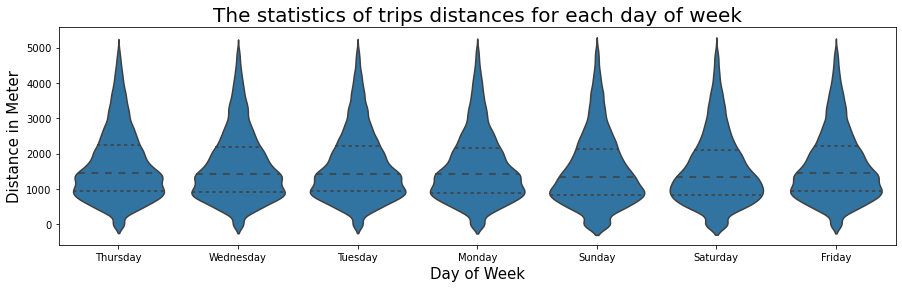

```python
# use violin plot to describe the distribution of trips distances for each day of week.

plt.figure(figsize=[15, 4])
sb.violinplot(data=fordgobike2, x='start_day_ofweek', y='calc_dist', color=base_color, inner='quartile');
plt.title("The statistics of trips distances for each day of week", fontsize=20);
plt.xlabel('Day of Week', fontsize=15);
plt.ylabel('Distance in Meter', fontsize=15);
```

###### Observation: The distribution is almost the same for days of week.

### What is the descriptive statistics of trips durations over the day of week?

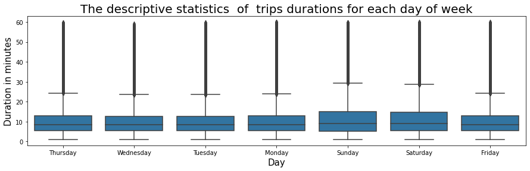

```python
plt.figure(figsize=[15, 4])
sb.boxplot(data=fordgobike1, x='start_day_ofweek', y='duration_min', color=base_color);
plt.title("The descriptive statistics  of  trips durations for each day of week", fontsize=20);
plt.xlabel('Day', fontsize=15);
plt.ylabel('Duration in minutes', fontsize=15);
```

###### The average trips duration is higher during weekend than work days.

### Talk about some of the relationships you observed in this part of the investigation. How did the feature(s) of interest vary with other features in the dataset?

Generally, There are more men than women using the service. But, The riding habit/pattern of women shows that they are use the service above 10 minutes in duration and over than 1 kilometer in distance with lower average velocity than men. The age of women using the service is slightly lower than men. The pattern of women trips shows also that the ratio of trips at weekkend to the total week days is higher for women than men which indicates that women perfer to use the service as a picnic than work transportation.

### Did you observe any interesting relationships between the other features (not the main feature(s) of interest)?

It is interesting to explore the relation between the subscribers and zero distance trips over the hour of day

## Multivariate Exploration

### First, lets explore the bike rides by gender:

### What is the distribution of the number and average duration of trips over the day of week for each gender?

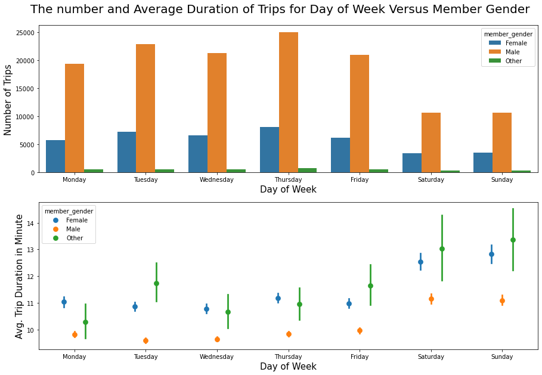

```python
plt.figure(figsize=[15, 10])

# Use the clustered bar chart to describe the distribution of the number of trips versus the day of week for each member gender
plt.suptitle('The number and Average Duration of Trips for Day of Week Versus Member Gender', fontsize=20, y=0.93)
order_days = ('Monday', 'Tuesday', 'Wednesday', 'Thursday', 'Friday', 'Saturday', 'Sunday' )
plt.subplot(2, 1, 1)
sb.countplot(data = fordgobike, x = 'start_day_ofweek', hue = 'member_gender', order = order_days);
plt.xlabel('Day of Week', fontsize=15);
plt.ylabel('Number of Trips', fontsize=15);

# Use the clustered bar chart to describe the distribution of the trips average durations versus the day of week for each member gender
plt.subplot(2, 1, 2)
sb.pointplot(data=fordgobike1, x='start_day_ofweek', y='duration_min', hue='member_gender', order = order_days, dodge=0.3, linestyles="");
plt.xlabel('Day of Week', fontsize=15);
plt.ylabel('Avg. Trip Duration in Minute', fontsize=15);
```

###### Observation: Although men are represents 75% of the reiders and consequently have larger numer of trips than women, but women have average trips duration larger than men especially at weekends.

### What is the distribution of the number and average duration of trips over the hour of day for each gender?

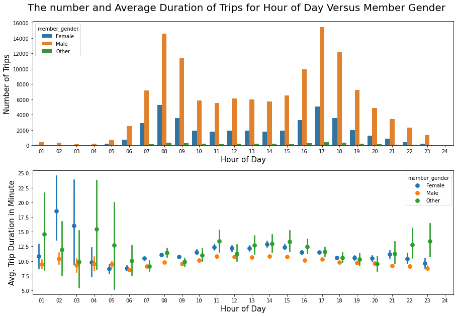

```python
plt.figure(figsize=[15, 10])
plt.suptitle('The number and Average Duration of Trips for Hour of Day Versus Member Gender', fontsize=20, y=0.93)
order_hours = ('01', '02', '03', '04', '05', '06', '07', '08', '09', '10', '11', '12', '13', '14', '15', '16', '17', '18', '19', '20', '21', '22', '23', '24')
# Use the clustered bar chart to describe the distribution of the number of trips versus the hour of day for each member gender

plt.subplot(2, 1, 1)
sb.countplot(data = fordgobike, x = 'start_hour_ofday', hue = 'member_gender', order = order_hours);
plt.xlabel('Hour of Day', fontsize=15);
plt.ylabel('Number of Trips', fontsize=15);

# Use the clustered bar chart to describe the distribution of the trips average durations versus the hour of day for each member gender

plt.subplot(2, 1, 2)
sb.pointplot(data=fordgobike1, x='start_hour_ofday', y='duration_min', hue='member_gender', order = order_hours, dodge=0.3, linestyles="");
plt.xlabel('Hour of Day', fontsize=15);
plt.ylabel('Avg. Trip Duration in Minute', fontsize=15);
```

###### Observation: This pattern shows that women doesn't prefer using the service for work transportation than Exercising out of work times

### Next up, lets explore the bike rides at weekend and work days:

### What is the distribution of the number and average duration of trips over the hour of day for each day type?

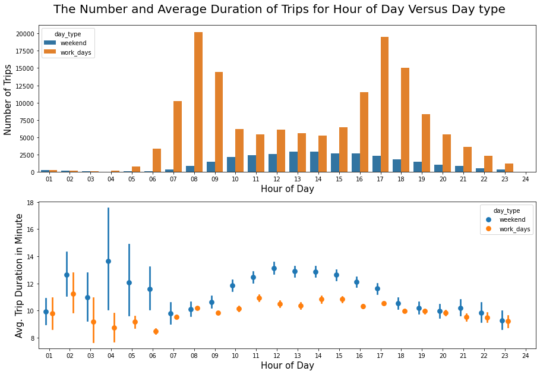

```python
plt.figure(figsize=[15, 10])
plt.suptitle('The Number and Average Duration of Trips for Hour of Day Versus Day type', fontsize=20, y=0.93)

# Use the clustered bar chart to describe the distribution of the number of trips versus the hour of day for each day type

plt.subplot(2, 1, 1)
sb.countplot(data = fordgobike, x = 'start_hour_ofday', hue = 'day_type', order = order_hours);
plt.xlabel('Hour of Day', fontsize=15);
plt.ylabel('Number of Trips', fontsize=15);

# Use the clustered bar chart to describe the distribution of the trips durations versus the hour of day for each day type

plt.subplot(2, 1, 2)
sb.pointplot(data=fordgobike1, x='start_hour_ofday', y='duration_min', hue='day_type', order = order_hours, dodge=0.3, linestyles="");
plt.xlabel('Hour of Day', fontsize=15);
plt.ylabel('Avg. Trip Duration in Minute', fontsize=15);
```

### What is the distribution of the number and average duration of trips over the member ages for each day type?

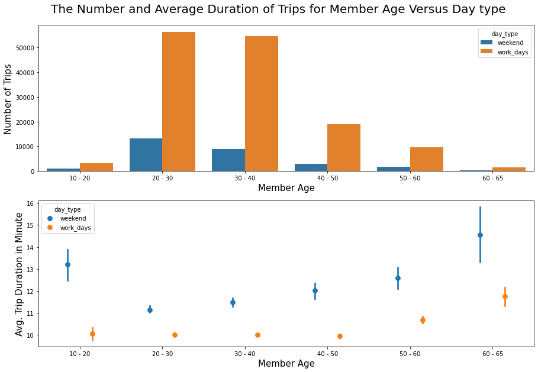

```python
# Create a new field for member age group from member_age column order
fordgobike3['age_bins'] = fordgobike3['member_age'].apply(lambda x: '10 - 20' if 10<x<=20
                                                  else '20 - 30' if 20<x<=30
                                                  else '30 - 40' if 30<x<=40
                                                  else '40 - 50' if 40<x<=50
                                                  else '50 - 60' if 50<x<=60
                                                  else '60 - 65' if 60<x<=65
                                                  else x);
fordgobike5 = fordgobike3[fordgobike['duration_min'] < 60]

# plot The Number and Average Duration of Trips for member age Versus Day type
plt.figure(figsize=[15, 10])
plt.suptitle('The Number and Average Duration of Trips for Member Age Versus Day type', fontsize=20, y=0.93)
order_age = ('10 - 20', '20 - 30', '30 - 40', '40 - 50', '50 - 60', '60 - 65')

plt.subplot(2, 1, 1)
sb.countplot(data = fordgobike5, x = 'age_bins', hue = 'day_type', order = order_age);
plt.xlabel('Member Age', fontsize=15);
plt.ylabel('Number of Trips', fontsize=15);

plt.subplot(2, 1, 2)
sb.pointplot(data=fordgobike5, x='age_bins', y='duration_min', hue='day_type', dodge=0.3, linestyles="", order = order_age);
plt.xlabel('Member Age', fontsize=15);
plt.ylabel('Avg. Trip Duration in Minute', fontsize=15);
```

###### Observation: The duration of trips show that the trips at weekends have a much higher average durations for the younger and older riders.

### What is the number and average duration of trips for the user types for each day type?

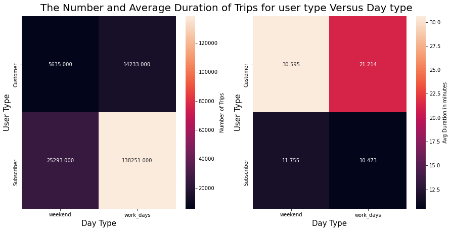

```python
# Use the heat map to show the Number and average duration of trips Versus yser types for each day type

plt.figure(figsize=[15, 7])
plt.suptitle('The Number and Average Duration of Trips for user type Versus Day type', fontsize=20, y=0.93)

plt.subplot(1, 2, 1)

day_user = fordgobike.groupby(['day_type', 'user_type']).count()["bike_id"]
day_user = day_user.reset_index(name = 'num_trips')
day_user = day_user.pivot(index = 'user_type', columns = 'day_type',
                            values = 'num_trips')
sb.heatmap(day_user, annot = True, fmt = '.3f',
           cbar_kws = {'label' : 'Number of Trips'});
plt.xlabel('Day Type', fontsize=15);
plt.ylabel('User Type', fontsize=15);


plt.subplot(1, 2, 2)

day_user = fordgobike.groupby(['day_type', 'user_type']).mean()['duration_min']
day_user = day_user.reset_index(name = 'avg_duration')
day_user = day_user.pivot(index = 'user_type', columns = 'day_type',
                            values = 'avg_duration')
sb.heatmap(day_user, annot = True, fmt = '.3f',
           cbar_kws = {'label' : 'Avg Duration in minutes'});
plt.xlabel('Day Type', fontsize=15);
plt.ylabel('User Type', fontsize=15);
```

###### Observation: The customers have constant usage of the service along the week days which reflects that at weekend at which the suscribers have a low service usage, the customers have an average duration of trips higher than the suscribers.

### Talk about some of the relationships you observed in this part of the investigation. Were there features that strengthened each other in terms of looking at your feature(s) of interest?

The multivariate exploration strengthened some of the patterns discovered in the previous bivariate exploration as well as univariate exploration:

1- Although men are represents 75% of the reiders and consequently have larger numer of trips than women, but women have average trips distance and duration larger than men especially at weekends. This pattern shows that women doesn't prefer using the service for work transportation than Exercising out of work times, this may be beacause of the physical exertion of bike riding or women work dressing style which doesn't convenient with bike pedaling. So that, ebikes those taking some of the effort out of pedaling will be an apporiate solution to increase the number of women riders.

2- The number of trips show that the work days obsesse the most trips beacasue that the service is mainly used for work transportation especially at the ruch hours of going to (07, 08, 09) and from work (16, 17, 18). While, the duration of trips show that the trips at weekends have a much higher average durations for the younger and older riders. Also, the customers have constant usage of the service along the week days which reflects that at weekend at which the suscribers have a low service usage, the customers have an average duration of trips higher than the suscribers. So that, the company should creates a special package for the weekend riding which will encourage much people whose prefer using the bikes as Exercising rather than work transportation to use the services.